# Wprowadzenie do statystyki Bayesowskiej

## Opis warsztatu

| D1/10:00 | Wprowadzenie do statystyki Bayesowskiej |
| --- | --- |
| D1/11:45 | Powtórka z R i wprowadzenie do MCMC |
| D1/14:00 | brms: regresja prosta i porównywanie średnich |
| D1/15:45 | brms: regresja wielokrotna + a. moderacji |
| D2/10:00 | brms: Bayesowska ANOVA |
| D2/11:45 | brms: Bayesowski HLM |
| D2/14:00 | brms: Bayesowskie uogólnione modele liniowe |
| D2/15:45 | Testowanie hipotez i porównywanie modeli |

## Opis oprogramowania

- R + RStudio + RStudio Noteboooks
- pakiety:
  - tidyverse
  - brms
  - emmeans
  - bayestestR
  - tidybayes

## Inne programy oferujące metody Bayesowskie

- Większość współczesnych pakietów statystycznych oferuje jakiś rodzaj metod Bayesowskich:
  - Stata
  - SAS
  - MPlus
  - SPSS/Amos
  - JASP
  - WinBUGS
  - JAGS
  - Python - Pymc3
  - Julia - Turing

## Książki na temat analizy Bayesowskiej

[figure not shown]

## Książki na temat analizy Bayesowskiej

[figure not shown]

## Książki na temat analizy Bayesowskiej

[figure not shown]

## Książki na temat analizy Bayesowskiej

[figure not shown]

## Książki na temat analizy Bayesowskiej

[figure not shown]

## Materiały dostępne online:

- Blogi na temat pakietu `brms`: [tutaj](https://paul-buerkner.github.io/blog/brms-blogposts/)
- Case studies z użyciem programu `Stan`: [tutaj](https://mc-stan.org/users/documentation/case-studies.html)
- Przykłady z książki ‘Statistical rethinking’ w `brms`: [tutaj](https://bookdown.org/connect/#/apps/1850/access)
- Przykłady z książki ‘Introduction to Mediation, Moderation, and Conditional Process Analysis’ Andrew Hayesa w `brms`: [tutaj](https://bookdown.org/connect/#/apps/1523/access)
- Przykłady z książki ‘DBDA2ed’ Kruscke’go w `brms`: [tutaj](https://bookdown.org/ajkurz/DBDA_recoded/)

## Twierdzenie Bayesa

\[Pr(A | B) = \frac{Pr(B | A) \times Pr(A)}{Pr(B)}\]

## Twierdzenie Bayesa

- Jak bardzo możemy być pewni statystycznie istotnego wyniku…
- jeżeli przeprowadziliśmy badanie o mocy .80 i uzyskaliśmy istotny statystcznie wynik, p < .05?
- Moc .80 oznacza, że jeżeli nasza hipoteza (H1 = prawda) jest prawdziwa, na 1000 badań w 800 uzyskamy istotny wynik.
- Wartość p oznacza, że jeżeli nasza hipoteza jest fałszywa (H0 = prawda), na 1000 badań w 50 uzyskamy istotny wynik.
- Nie wiemy jak dużo hipotez badawczych jest prawdziwe. Przypuśćmy, że jest to jednak tylko mały odsetek, 10 na 1000.
- Jakie jest prawdopodobieństwo, że nasza hipoteza jest prawdziwa jeżeli uzyskaliśmy istotny wynik?

## Twierdzenie Bayesa

|  | H0 = prawda | H1 = prawda |
| --- | --- | --- |
| p < .05 |  |  |
| p > .05 |  |  |
|  | **990** | **10** |

## Twierdzenie Bayesa

|  | H0 = prawda | H1 = prawda |
| --- | --- | --- |
| p < .05 |  | 8 |
| p > .05 |  | 2 |
|  | **990** | **10** |

## Twierdzenie Bayesa

[output not shown]

## Twierdzenie Bayesa

- Na 1000 badań, wśród wszystkich 58 istotnych testów statystycznych
  - 8 jest przejawem tego, że nasza hipoteza jest prawdziwa
  - 50 wynika z przypadku
- Prawdopodobieństwo, że nasza hipoteza jest prawdziwa wynosi: 8/58 = 0.137931

## Twierdzenie Bayesa

\[Pr(H_1 | p < .05) = \frac{Pr(p < .05 | H_1) \times Pr(H_1)}{[Pr(p < .05 | H_1) \times Pr(H_1)] + [Pr(p < .05 | H_0) \times Pr(H_0)]}\]

## Twierdzenie Bayesa

\[Pr(H_1 | p < .05) = \frac{.80 \times .01}{[.80 \times .01] + [.05 \times .99]} \approx .14\]

## Jak szybko policzyć Pr dla H1?

[When does a significant p-value indicate a true effect?](http://shinyapps.org/apps/PPV/)

## Zastosowanie twierdzenia Bayesa w modelowaniu statystycznym

\[Posterior = \frac{Likelihood \times Prior}{Average\ Likelihood}\]

## Zastosowanie twierdzenia Bayesa w modelowaniu statystycznym

\[Pr(parametry | dane) = \frac{Pr(dane | parametry) \times Pr(parametry)}{Pr(dane)}\]

## Zastosowanie twierdzenia Bayesa w modelowaniu statystycznym

\[Pr(\theta| \mathcal{D}) = \frac{Pr(\mathcal{D} | \theta) \times Pr(\theta)}{\int Pr(\mathcal{D} | \theta) \times Pr(\theta) \mathrm{d}\theta}\]

## Wnioskowanie Bayesowskie

- Przypuśćmy, że chcemy oszacować ile osób w populacji ma specyficzny profil osobowości.
- Dysponujemy kwestionariuszem, który mierzy taki profil bezbłędnie.
- Zaczynamy badanie na losowej, reprezentatywnej próbie osób.
- Otrzymujemy po kolej wyniki (P = pozytywne lub N = negatywne)
- P, N, N, P, P, N, N, N, N, N

## Wnioskowanie Bayesowskie

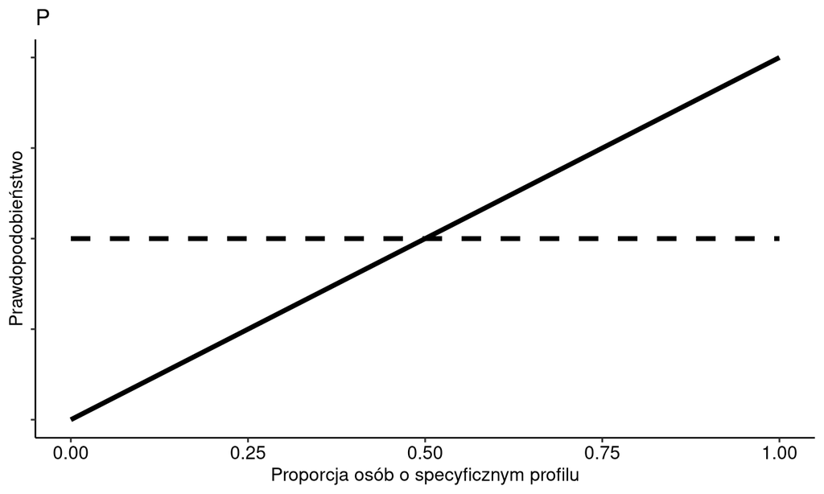

## Wnioskowanie Bayesowskie

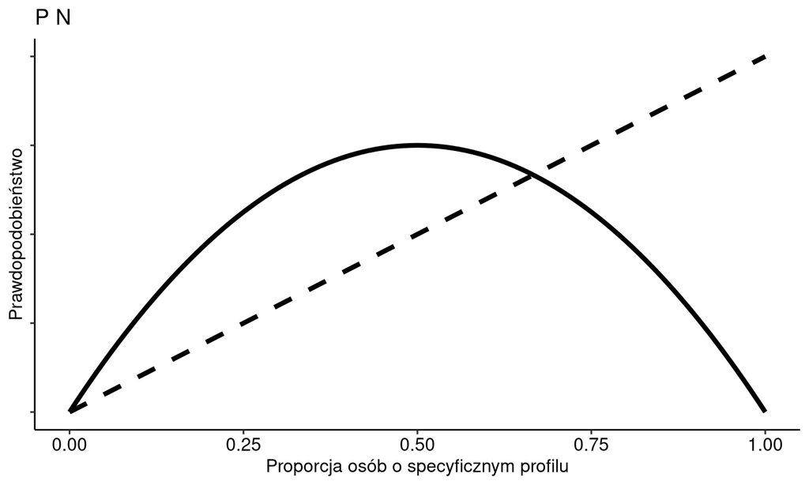

## Wnioskowanie Bayesowskie

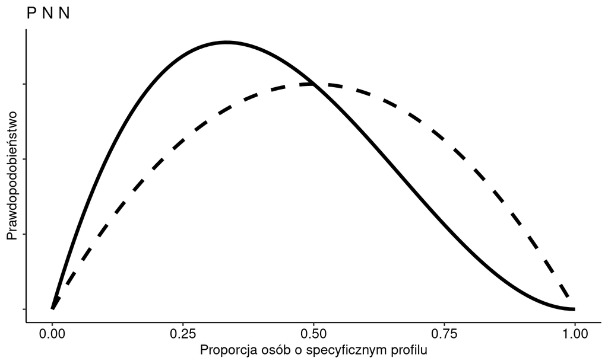

## Wnioskowanie Bayesowskie

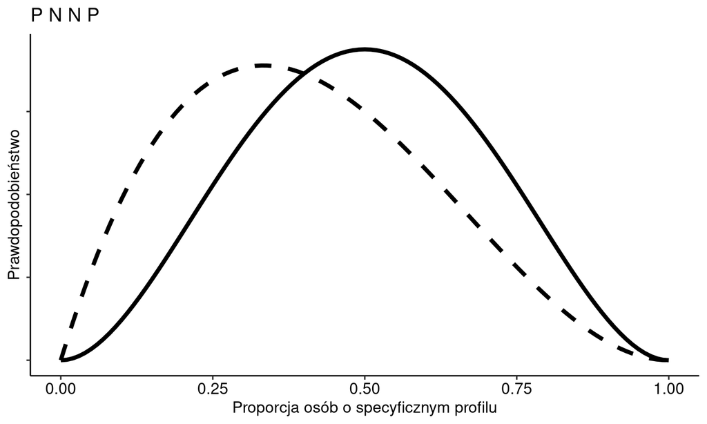

## Wnioskowanie Bayesowskie

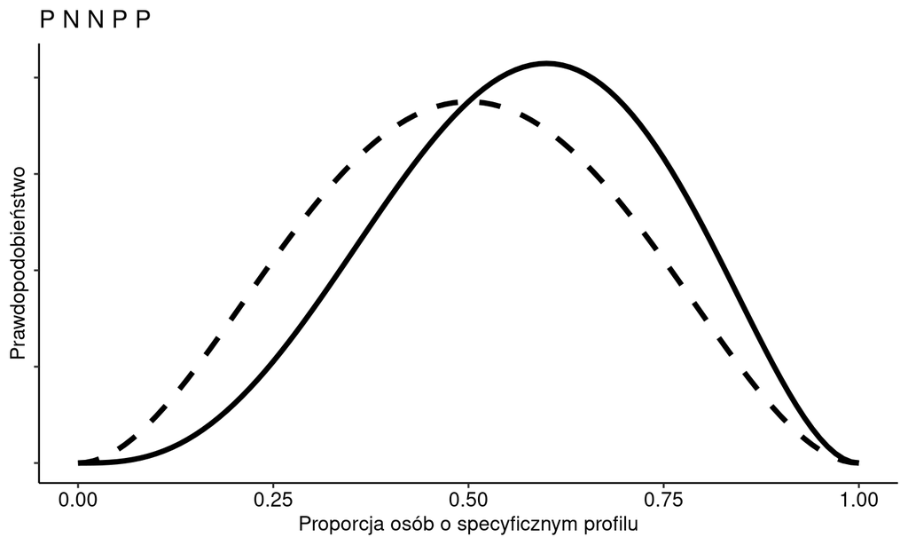

## Wnioskowanie Bayesowskie

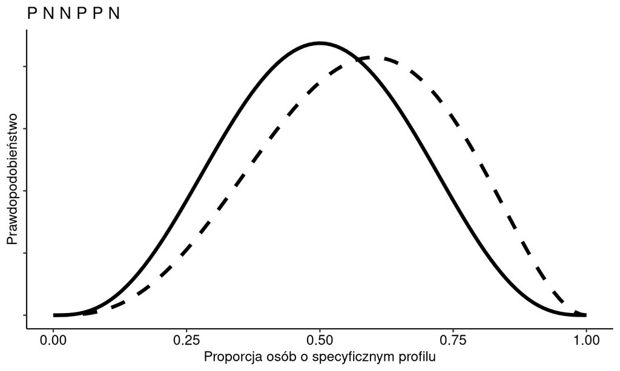

## Wnioskowanie Bayesowskie

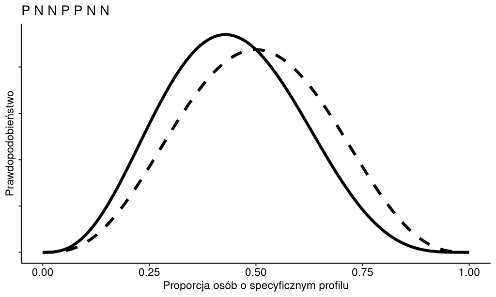

## Wnioskowanie Bayesowskie

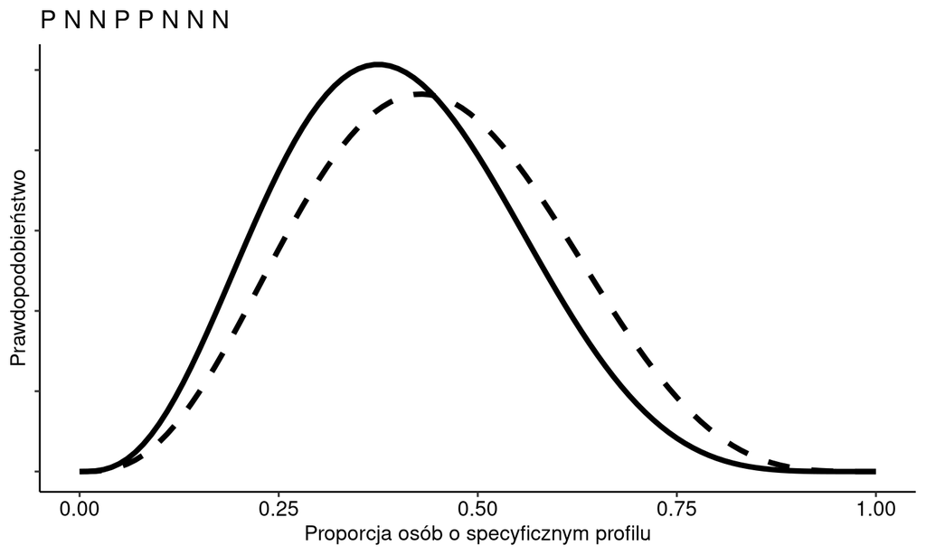

## Wnioskowanie Bayesowskie

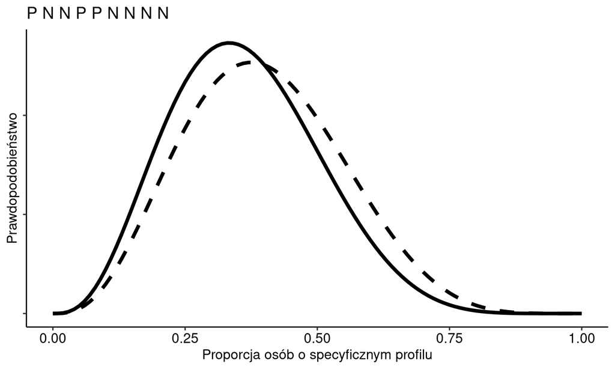

## Wnioskowanie Bayesowskie

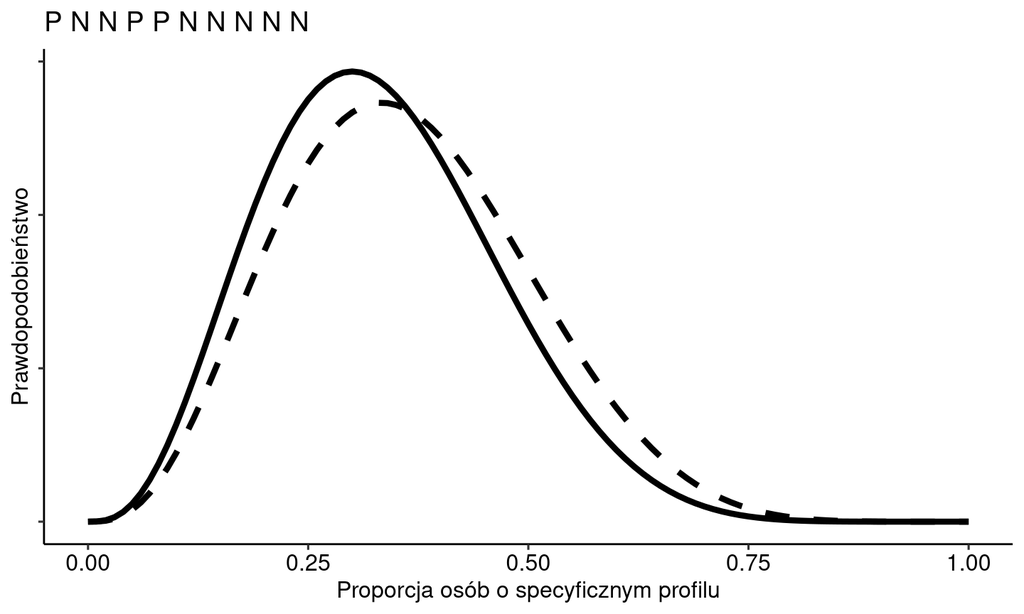